# Effectiveness of Math Placement Test, Calculus Readiness Test, and SOAR Program

August 01, 2018 at 12:03:59 PM

## Purpose

#### Effectiveness of Math Placement Test, Calculus Readiness Test and SOAR at Appalachian

- College costs have grown substantially
- Students and government are looking to reduce costs
  - Adding or removing programs
  - Adjusting Tests

## Math Placement Test

#### The MPT is a 30 minute 25 question test designed to test a students aptitude of basic high school algebra.

#### Students take the MPT if they meet all of the following:

- SAT Math score is less than 550
- Have not received AP Credit
- Have not received transfer credit for a math course

## Plot of Combined Data

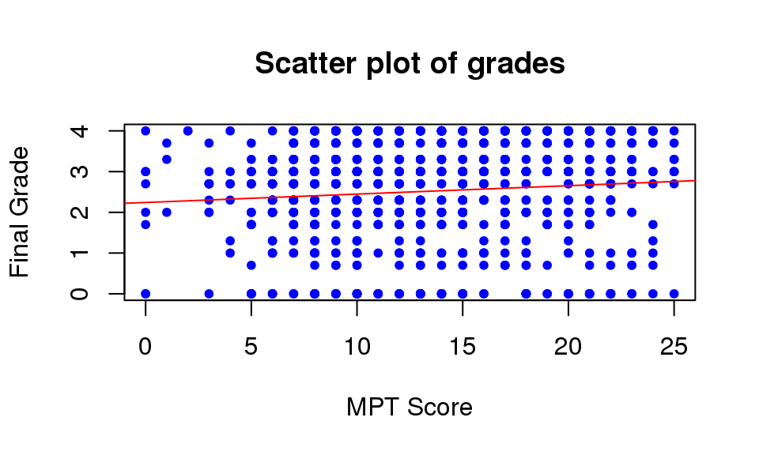

The \(r^2\) is 0.0089059.

## Plots Factored by Class

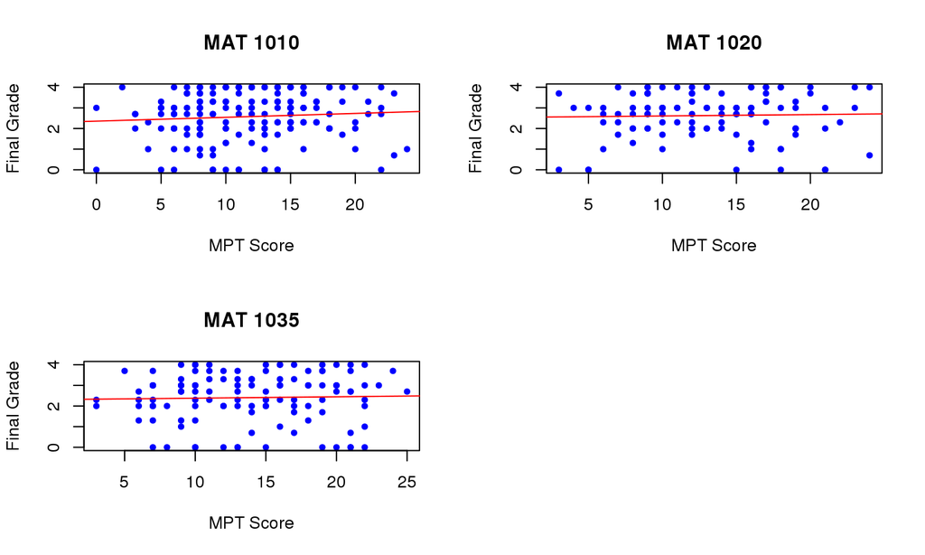

## Plots Factored by Class (Continued)

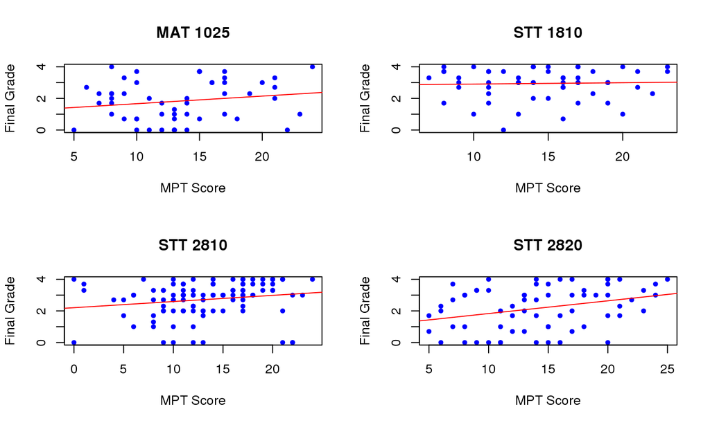

## Correlation Coefficients

[output not shown]

## Plots with students who scored 10 or better

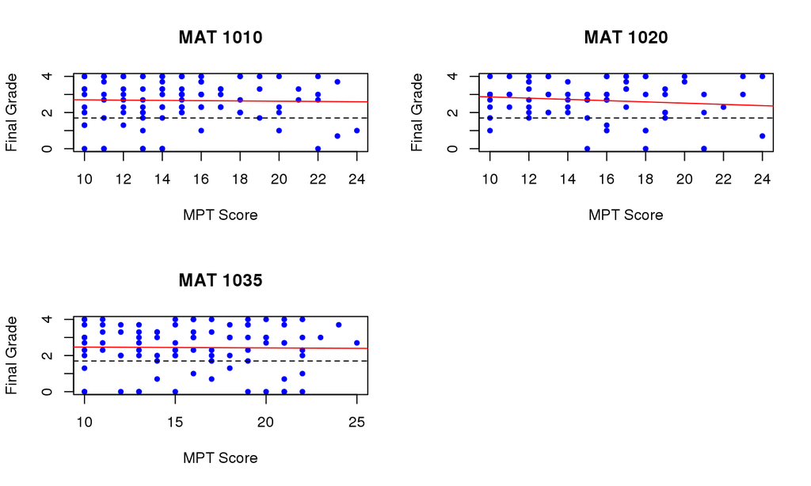

## Plots with students who scored 10 or better (Continued)

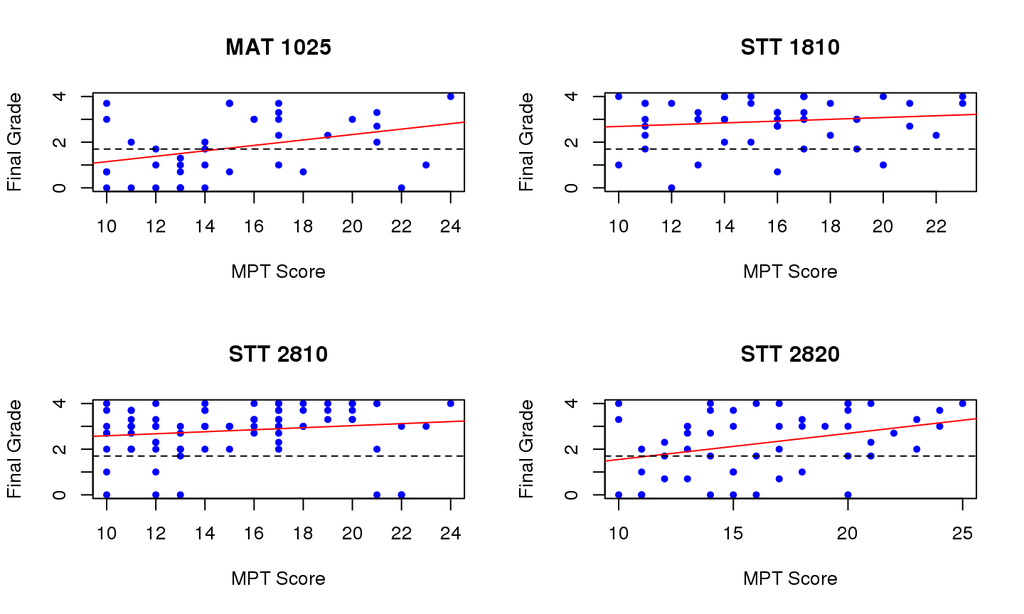

## Slopes of Factored Plots

| Course | slopes |
| --- | --- |
| MAT 1010 | -0.0076 |
| MAT 1020 | -0.0345 |
| MAT 1035 | -0.0048 |
| MAT 1025 | 0.1189 |
| STT 1810 | 0.039 |
| STT 2810 | 0.0444 |
| STT 2820 | 0.1145 |

## Pass Fail Percentages

| Course | MAT 1010 | MAT 1020 | MAT 1035 | MAT 1025 | STT 1810 | STT 2810 | STT 2820 | ALL |
| --- | --- | --- | --- | --- | --- | --- | --- | --- |
| Passed | 84.8 % | 86.3 % | 79.8 % | 52.5 % | 89.6 % | 90.4 % | 72.5 % | 81.6 % |
| Failed | 15.2 % | 13.7 % | 20.2 % | 47.5 % | 10.4 % | 9.6 % | 27.5 % | 18.4 % |

## Five Step Population Proportion Hypothesis Test

#### Step 1: State The Hypothesis

The null hypothesis (\(H_0\)) is that the failure rate of the MPT is 10%. The alternate hypothesis (\(H_A\)) is that the failure rate is greater than 10%. We get the following:

\[ H_0 = .10\] \[ H_A > .10\]

#### Step 2: Identify the Test Statistic

The test statistic is the observed value that is being tested. In this case the test statistic is the proportion 18.4 %.

## Five Step Population Proportion Hypothesis Test (Continued)

#### Step 4: State a Statistical Conclusion

Since the \(p\)-value (0.000021) is less than the alpha value (0.10) the null hypothesis is rejected.

#### Step 5: State the English Conclusion

Based on this sample there is significant enough evidence to suggest that the proportion of students who fail there first math class after scoring a 10 or better on the MPT is greater than 10%.

## Threshold Score

| Score | Prop Fail | p-value | Score | Prop Fail | p-value |
| --- | --- | --- | --- | --- | --- |
| 1 | 18.882 | 0 | 11 | 17.273 | 0.0000002 |
| 2 | 18.939 | 0 | 12 | 17.588 | 0.0000002 |
| 3 | 18.968 | 0 | 13 | 17.270 | 0.0000022 |
| 4 | 19.018 | 0 | 14 | 15.335 | 0.0008271 |
| 5 | 18.981 | 0 | 15 | 15.672 | 0.0009836 |
| 6 | 18.641 | 0 | 16 | 16.143 | 0.0011148 |
| 7 | 18.421 | 0 | 17 | 16.484 | 0.0017739 |
| 8 | 18.621 | 0 | 18 | 19.565 | 0.0000900 |
| 9 | 18.574 | 0 | 19 | 18.919 | 0.0008674 |
| 10 | 18.405 | 0 | 20 | 22.727 | 0.0000345 |

## Calculus Readiness Test

#### The CRT is a 50 minute 25 question test designed to test a students aptitude of basic high school algebra 2 and trigonometry.

#### Students take the CRT if they plan on majoring in the following:

- Mathematics
- Computer science
- Pre-engineering
- Science

## Exploring the Data

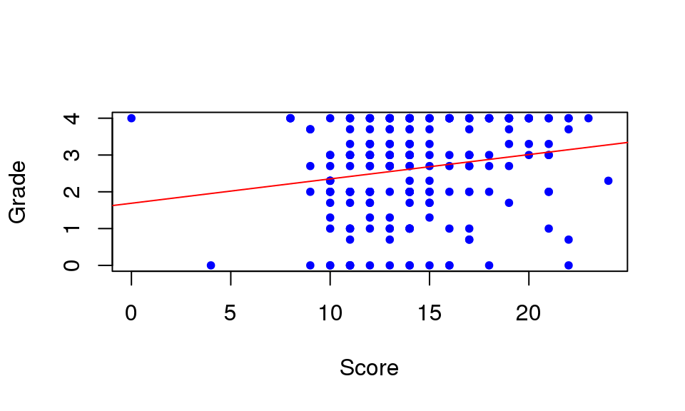

The \(r^2\) is 0.0368441.

## Five Step Population Proportion Hypothesis Test

#### Step 1: State The Hypothesis

The null hypothesis (\(H_0\)) is that the failure rate of the CRT is 10%. The alternate hypothesis (\(H_A\)) is that the failure rate is greater than 10%. We get the following:

\[ H_0 = .10\] \[ H_A > .10\]

#### Step 2: Identify the Test Statistic

The test statistic is the observed value that is being tested. In this case the test statistic is the 18.5 % of student failures.

## Five Step Population Proportion Hypothesis Test (Continued)

#### Step 3: Calculate the Rejection Region

\[ \mbox{SD} = \sqrt{\frac{pq}{n}} = \sqrt{\frac{0.1 *0.9}{214}} = 0.02050758\] \[ z = \frac{\hat{p}-p}{SD} = \frac{0.185-0.1}{0.02050758} = 4.144809\] \[ p-\mbox{value}= P(z>= 4.144809) = 0.000017\]

#### Step 4: State a Statistical Conclusion

Since the \(p\)-value (0.000017) is less than the alpha value (0.10) the null hypothesis is rejected.

#### Step 5: State the English Conclusion

Based on this sample there is significant enough evidence to suggest that the proportion of students who fail MAT 1110 after scoring an 11 or better on the CRT is greater than 10%.

## Threshold Scores

| Score | Prop Fail | p-value | Score | Prop Fail | p-value |
| --- | --- | --- | --- | --- | --- |
| 1 | 19.159 | 4.20e-06 | 11 | 16.355 | 0.0017943 |
| 2 | 19.159 | 4.20e-06 | 12 | 12.617 | 0.1312435 |
| 3 | 19.159 | 4.20e-06 | 13 | 11.215 | 0.3158973 |
| 4 | 19.159 | 4.20e-06 | 14 | 8.879 | 0.6569607 |
| 5 | 18.692 | 1.23e-05 | 15 | 5.607 | 0.9075818 |
| 6 | 18.692 | 1.23e-05 | 16 | 4.673 | 0.9284375 |
| 7 | 18.692 | 1.23e-05 | 17 | 3.271 | 0.9533760 |
| 8 | 18.692 | 1.23e-05 | 18 | 1.869 | 0.9586703 |
| 9 | 18.692 | 1.40e-05 | 19 | 1.402 | 0.9475185 |
| 10 | 18.224 | 4.51e-05 | 20 | 1.402 | 0.9054702 |

## STEM Opportunites Are Realized

- Extra support in math and chemistry
- For:
  - Students who have an SAT-Math score less than 550
  - ACT-Math score less than 22
  - SOAR also aims to support first year students

## Exploring the data

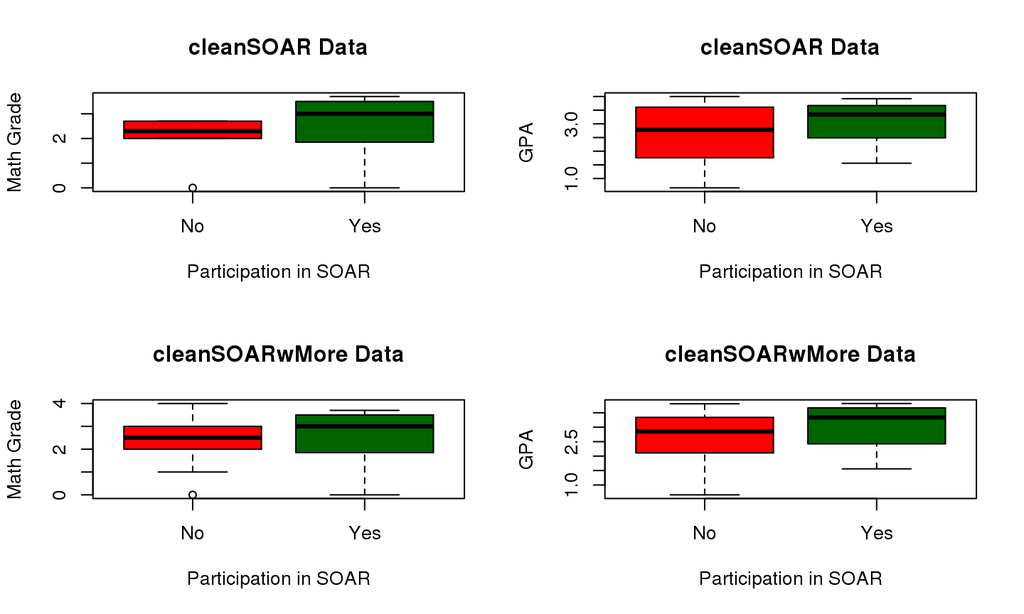

## Mean Grade Point Average

|  | SOAR | NONSOAR | Difference |
| --- | --- | --- | --- |
| cleanSOAR | 3.086 | 2.578 | 0.508 |
| cleanSOARwMore | 3.086 | 2.630 | 0.456 |

## Five Step Permutation Test

#### Step 1: State The Hypothesis

The null hypothesis is that the mean GPA of students in STEM related majors who participated in the SOAR program is no different than the mean GPA of the students in STEM related majors who didn't participate in the SOAR program. The alternate hypothesis is that the students who participated in the SOAR program have a higher mean GPA than the students who did not participate in the SOAR program.

\[H_0: \mu_{\mbox{GPA SOAR}} - \mu_{\mbox{GPA nonSOAR}} = 0\] \[H_0: \mu_{\mbox{GPA SOAR}} - \mu_{\mbox{GPA nonSOAR}} > 0\]

#### Step 2: Identify the Test Statistic

The test statistic is the observed value that is being tested. In this case the test statistic is the difference of 0.508.

## Five Step Permutation Test (Continued)

#### Step 3: Calculate the Rejection Region

Using the permutation test we can see that we have a p-value of 0.0588941.

#### Step 4: State a Statistical Conclusion

Since the p-value (0.0588941) is less than the alpha value (0.10) the null hypothesis is rejected.

#### Step 5: State the English Conclusion

Based on this sample there is significant enough evidence to suggest that the students who are STEM majors and attend the SOAR program have a higher GPA than students who are STEM majors and do not participate in the SOAR program.

## Five Step Permutation Test

#### Step 1: State The Hypothesis

The null hypothesis is that the mean GPA of students in STEM related majors, who took a math class, and participated in the SOAR program is no different than the mean GPA of the students in STEM related majors who took a math class, and didn't participate in the SOAR program. The alternate hypothesis is that the students who participated in the SOAR program have a higher mean GPA than the students who did not participate in the SOAR program.

\[H_0: \mu_{\mbox{GPA SOARw/math}} - \mu_{\mbox{GPA nonSOARw/math}} = 0\] \[H_0: \mu_{\mbox{GPA SOARw/math}} - \mu_{\mbox{GPA nonSOARw/math}} > 0\]

#### Step 2: Identify the Test Statistic

The test statistic is the observed value that is being tested. In this case the test statistic is the difference of 1.005.

## Five Step Permutation Test (Continued)

#### Step 3: Calculate the Rejection Region

The \(p\)-value is 0.0079992.

#### Step 4: State a Statistical Conclusion

Since the p-value (0.0079992) is less than the alpha value (0.10) the null hypothesis is rejected.

#### Step 5: State the English Conclusion

Based on this sample there is significant enough evidence to suggest that the students who are STEM majors, that take a math class, and attend the SOAR program have a higher GPA than students who are STEM majors, that take a math class, and do not participate in the SOAR program.

## Five Step Permutation Test

#### Step 1: State The Hypothesis

The null hypothesis is that the mean GPA of students who applied to SOAR, took a math class, and participated in the SOAR program is no different than the mean GPA of the students who applied to SOAR, who took a math class, and didn't participate in the SOAR program. The alternate hypothesis is that the students who participated in the SOAR program have a higher mean GPA than the students who did not participate in the SOAR program.

\[H_0: \mu_{\mbox{GPA SOARwMore/math}} - \mu_{\mbox{GPA nonSOARwMore/math}} = 0\] \[H_0: \mu_{\mbox{GPA SOARwMore/math}} - \mu_{\mbox{GPA nonSOARwMore/math}} > 0\]

## Five Step Permutation Test (Continued)

#### Step 3: Calculate the Rejection Region

The \(p\)-value is 0.0541946.

#### Step 4: State a Statistical Conclusion

Since the p-value (0.0541946) is less than the alpha value (0.10) the null hypothesis is rejected.

#### Step 5: State the English Conclusion

Based on this sample there is significant enough evidence with an alpha value of 0.10 to suggest that the students who are applied to SOAR, that take a math class, and attend the SOAR program have a higher GPA than students who are applied to SOAR, that take a math class, and do not participate in the SOAR program.

## Conclussion

- Math Placement Test does not meet the criteria of 10% or less failures
  - More analysis done based specific classes
  - Possibly conduct a strategized analysis based on class standing
- Calculus Readiness Test threshold score needs to be adjusted but is effective
  - Conduct a thorough analysis by comparing SOAR to ALEKS
- SOAR program based on current data shows evidence that it is achieving its goal
  - More analysis with basis on chemistry as well

## References

- Chihara, Laura M.; Hesterberg, Tim C.; *Mathematical Statistics with Resampling and R*, John Wiley & Sons, 2012.
- De Veaux; Velleman; and Bock; *Stats: Data and Models*, Pearson Education, 2016.
- Ugarte, Maria D.; Militino, Ana F.; Arnholt, Alan T.; *Probability and Statistics with R, Second Edition*, CRC Press, 2016.
- *Math Placement and Calculus Readiness Tests*, Appalachian State University, 8 Aug. 2018, https://orientation.appstate.edu/course-registration-placement-testing/math-placement-and-calculus-readiness-tests.